# OTX2 case study - Fig 3b

Top 5 TF motifs enriched in 4C OTX2 CUT&RUN peaks (HOMER known motif enrichment, one-sided binomial).

Paper reports **OTX2, GSC, DUX4, CRX, PHOX2A** as the top 5 (P-values 10^-4544 to 10^-598). Exact ranks and P-values depend on the HOMER motif-database version. Our run recovers the same TF family (Homeobox, TAATCC-core recognition) in the top hits.

Paper: Wang, Q. *et al.* Maternal factor *OTX2* regulates human embryonic genome activation and early development. *Nature Genetics* **57**, 2772-2784 (2025). 10.1038/s41588-025-02350-8

### Data availability

Input peak list for HOMER comes from OMIX006476's `h_OTX2_day2_CUTRUN_rep12_peaks.bed` (n = 45,521 4C OTX2 CUT&RUN peaks). This is the BED form of Supp Table S7 — identical rows, no xlsx parsing needed.

hg19 genome assembly: `/scratch/users/steorra/data/hg19/hg19.fa`.

## Upstream processing (documented, not executed)

The cells in this section are wrapped in `%%script false --no-raise-error` so they **do not run**; they exist to document the full pipeline from raw FASTQ / GEO accession down to the cached inputs that the runnable cells below consume. Run them once from a shell if you are rebuilding `/scratch/users/steorra/data/otx2/` from scratch.

### Reference (hg19)

```python
%%script false --no-raise-error
# ==========================================================
# hg19 reference + GENCODE v41lift37 annotation + bowtie2 index
# ==========================================================
cd /scratch/users/steorra/data/hg19
wget -c https://hgdownload.soe.ucsc.edu/goldenPath/hg19/bigZips/hg19.fa.gz
gunzip hg19.fa.gz && samtools faidx hg19.fa
cut -f1,2 hg19.fa.fai > hg19.chrom.sizes

wget -c https://ftp.ebi.ac.uk/pub/databases/gencode/Gencode_human/release_41/GRCh37_mapping/gencode.v41lift37.annotation.gtf.gz

bowtie2-build --threads 8 hg19.fa bt2_idx/hg19
```

### Supplementary tables (source of the peak input)

```python
%%script false --no-raise-error
# ==========================================================
# Nature Genetics supplementary tables S1-S7
# ==========================================================
# Downloaded from the article HTML (Springer). Save as:
#   /scratch/users/steorra/data/otx2/supp/supp_tables.xlsx
# The sheet names used throughout these notebooks:
#   Table S3_stage-activated genes   — per-stage activated gene lists
#   Table S4_OTX2 KD_RNA count       — raw count matrix for RNA-KD
#   Table S6_DEG                     — DESeq2 DEG blocks (D2-KD, D3-KD, ...)
#   Table S7_4C OTX2_CUTRUN_peaks    — 4C OTX2 peak list (n=45,521)
echo "See paper Supplementary Information on the Nature article page."
```

### CUT&RUN FASTQ → BAM (source of Supp Table S7 peaks)

```python
%%script false --no-raise-error
# ==========================================================
# CUT&RUN FASTQ -> deduplicated BAM -> RPKM-normalised bigwig
# ==========================================================
# Reference: Wang et al. 2025 Methods ("CUT&RUN assay" section) +
# filename convention in OMIX006476 (`..._pmu_100bp_rpkm_bamCoverage.bw`).
#
# Raw FASTQs are hosted behind controlled access at GSA-Human HRA006621
# (paper Data Availability). For each replicate:
SAMPLE=h_OTX2_day2_CUTRUN_rep1         # one of rep1 / rep2 / KD etc.
FQDIR=/scratch/users/steorra/data/otx2/HRA006621/fastq
BAMDIR=/scratch/users/steorra/data/otx2/OMIX006476/bam
BWDIR=/scratch/users/steorra/data/otx2/OMIX006476
IDX=/scratch/users/steorra/data/hg19/bt2_idx/hg19
mkdir -p $BAMDIR $BWDIR

# 1. Adapter / quality trim
trim_galore --paired --gzip -o $BAMDIR/trim \
    $FQDIR/${SAMPLE}_R1.fastq.gz $FQDIR/${SAMPLE}_R2.fastq.gz

# 2. Bowtie2 alignment (paired, CUT&RUN-optimised)
bowtie2 --end-to-end --very-sensitive --no-mixed --no-discordant \
        -I 10 -X 700 -p 8 -x $IDX \
        -1 $BAMDIR/trim/${SAMPLE}_R1_val_1.fq.gz \
        -2 $BAMDIR/trim/${SAMPLE}_R2_val_2.fq.gz |
    samtools view -bS -q 30 -f 2 - |
    samtools sort -@ 8 -o $BAMDIR/${SAMPLE}.raw.bam

# 3. Picard MarkDuplicates -> "pmu" (picard mark unique) BAM
picard MarkDuplicates \
    I=$BAMDIR/${SAMPLE}.raw.bam \
    O=$BAMDIR/${SAMPLE}.pmu.bam \
    M=$BAMDIR/${SAMPLE}.pmu.metrics REMOVE_DUPLICATES=true
samtools index $BAMDIR/${SAMPLE}.pmu.bam

# 4. Merge biological replicates (rep1 + rep2 -> rep12)
samtools merge -@ 8 -o $BAMDIR/h_OTX2_day2_CUTRUN_rep12.pmu.bam \
    $BAMDIR/h_OTX2_day2_CUTRUN_rep1.pmu.bam \
    $BAMDIR/h_OTX2_day2_CUTRUN_rep2.pmu.bam
samtools index $BAMDIR/h_OTX2_day2_CUTRUN_rep12.pmu.bam

# 5. RPKM bigwig (matches published file name)
bamCoverage -b $BAMDIR/h_OTX2_day2_CUTRUN_rep12.pmu.bam \
    -o $BWDIR/h_OTX2_day2_CUTRUN_rep12_pmu_100bp_rpkm_bamCoverage.bw \
    --binSize 100 --normalizeUsing RPKM -p 8
```

### MACS2 peak calling (Supp Table S7)

```python
%%script false --no-raise-error
# ==========================================================
# MACS2 peak calling on CUT&RUN BAMs
# (Supp Table S7 peaks + h_OTX2_day2_CUTRUN_rep12_peaks.bed)
# ==========================================================
BAMDIR=/scratch/users/steorra/data/otx2/OMIX006476/bam
PEAKDIR=/scratch/users/steorra/data/otx2/OMIX006476/peaks
mkdir -p $PEAKDIR

macs2 callpeak \
    -t $BAMDIR/h_OTX2_day2_CUTRUN_rep12.pmu.bam \
    -f BAMPE -g hs --nomodel --call-summits \
    --keep-dup all -q 0.01 \
    -n h_OTX2_day2_CUTRUN_rep12 --outdir $PEAKDIR
# -> $PEAKDIR/h_OTX2_day2_CUTRUN_rep12_peaks.narrowPeak  (distributed as _peaks.bed)
# Supp Table S7 is this peak set curated by the paper authors.
```

```python
import os, pathlib, warnings
os.environ['PATH'] = '/scratch/users/steorra/env/omicdev/bin:' + os.environ.get('PATH','')
warnings.filterwarnings('ignore')

import pandas as pd
import epione as epi
epi.pl.plot_set()

DATA    = pathlib.Path('/scratch/users/steorra/data/otx2')
OMIX    = DATA / 'OMIX006476'
HG19_FA = pathlib.Path('/scratch/users/steorra/data/hg19/hg19.fa')
MOTIF_DB = pathlib.Path('/scratch/users/steorra/env/omicdev/share/homer/data/knownTFs/vertebrates/known.motifs')
HOMER_OUT = pathlib.Path('/tmp/otx2_compare/fig3b/homer_out_py')
```

[output not shown]

### Motif enrichment via `epi.bulk.find_motifs_genome` (pure-Python, GPU)

Peak BED → GC-matched background (50k random genomic windows) → batched PWM scan on GPU (conv1d over one-hot sequences) → right-tailed binomial with arbitrary-precision tail for extreme p-values. Uses HOMER's own motif library as the PWM source so top hits are directly comparable to `findMotifsGenome.pl` output. Runs in ~2 min end-to-end on an H100 (vs ~15 min for the Perl pipeline).

```python
peaks = pd.read_csv(OMIX / 'h_OTX2_day2_CUTRUN_rep12_peaks.bed',
                    sep='\t', header=None,
                    names=['chrom','start','end','name','score'])

enrich = epi.bulk.find_motifs_genome(
    peaks, genome=HG19_FA, motif_library=MOTIF_DB,
    size=200, n_bg=50_000, seed=0,
    backend='auto',          # GPU if torch.cuda available, else CPU mp
    outdir=HOMER_OUT,        # writes HOMER-shaped knownResults + PWMs
    verbose=False,
)
print(enrich.head(5)[['Motif Name','Log P-value',
                      '% of Target Sequences with Motif',
                      '% of Background Sequences with Motif']])
```

```
                                          Motif Name   Log P-value  \
0  Otx2(Homeobox)/EpiLC-Otx2-ChIP-Seq(GSE56098)/H... -21961.359337
1  GSC(Homeobox)/FrogEmbryos-GSC-ChIP-Seq(DRA0005... -13890.270493
2  CRX(Homeobox)/Retina-Crx-ChIP-Seq(GSE20012)/Homer -11583.771207
3  Pitx1(Homeobox)/Chicken-Pitx1-ChIP-Seq(GSE3891...  -5654.047782
4  Mixl1(Homeobox)/EpiBlast-Mixl1-ChIP-seq(GSE161...  -2787.942285

   % of Target Sequences with Motif  % of Background Sequences with Motif
0                         39.834362                             10.160203
1                         53.474221                             21.426429
2                         67.215131                             33.540671
3                         78.049691                             53.191064
4                         17.745656                              8.168163
```

### Paper-style table via `epi.pl.homer_motif_table`

Reads the HOMER-shaped output directory that `find_motifs_genome` wrote and renders Rank | Logo | TF | P value for the top-5 unique TF families.

```
   TF                                               Motif Name       log10P
 OTX2       Otx2(Homeobox)/EpiLC-Otx2-ChIP-Seq(GSE56098)/Homer -9537.697175
  GSC  GSC(Homeobox)/FrogEmbryos-GSC-ChIP-Seq(DRA000576)/Homer -6032.467827
  CRX        CRX(Homeobox)/Retina-Crx-ChIP-Seq(GSE20012)/Homer -5030.767915
PITX1   Pitx1(Homeobox)/Chicken-Pitx1-ChIP-Seq(GSE38910)/Homer -2455.521752
MIXL1 Mixl1(Homeobox)/EpiBlast-Mixl1-ChIP-seq(GSE161164)/Homer -1210.787950
```

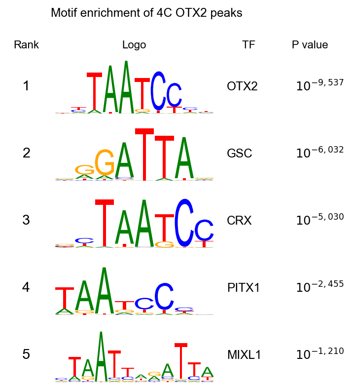

```python
fig, axes, top = epi.pl.homer_motif_table(
    HOMER_OUT, top_n=5, collapse_per_tf=True,
    title='Motif enrichment of 4C OTX2 peaks',
)
print(top[['TF','Motif Name','log10P']].to_string(index=False))
```